# NYPD_Shooting_Incident

MJF

2023-07-18

For this project I wanted to answer the question: Has shooting incidents increased in different burrows overtime? Some libraries you will need are: stringr, readr, tidyverse, and lubridate.

## Identify and import the data

Read in the data.

```r
# Save the link and read the csv.
link = "https://data.cityofnewyork.us/api/views/833y-fsy8/rows.csv?accessType=DOWNLOAD"
nypd_data = read.csv(link)
head(nypd_data)
```

```
##   INCIDENT_KEY OCCUR_DATE OCCUR_TIME     BORO LOC_OF_OCCUR_DESC PRECINCT
## 1    228798151 05/27/2021   21:30:00   QUEENS                        105
## 2    137471050 06/27/2014   17:40:00    BRONX                         40
## 3    147998800 11/21/2015   03:56:00   QUEENS                        108
## 4    146837977 10/09/2015   18:30:00    BRONX                         44
## 5     58921844 02/19/2009   22:58:00    BRONX                         47
## 6    219559682 10/21/2020   21:36:00 BROOKLYN                         81
##   JURISDICTION_CODE LOC_CLASSFCTN_DESC LOCATION_DESC STATISTICAL_MURDER_FLAG
## 1                 0                                                    false
## 2                 0                                                    false
## 3                 0                                                     true
## 4                 0                                                    false
## 5                 0                                                     true
## 6                 0                                                     true
##   PERP_AGE_GROUP PERP_SEX PERP_RACE VIC_AGE_GROUP VIC_SEX       VIC_RACE
```

[output cut: 20 more lines]

The data contains information about shooting incidents in NYC (INCIDENT_KEY, OCCUR_DATE, OCCUR_TIME, BORO, LOC_OF_OCCUR_DESC, PRECINCT, JURISDICTION_CODE, LOC_CLASSFCTN_DESC, LOCATION_DESC, STATISTICAL_MURDER_FLAG, PERP_AGE_GROUP, PERP_SEX, PERP_RACE, VIC_AGE_GROUP, VIC_SEX, VIC_RACE, X_COORD_CD, Y_COORD_CD, Latitude, Longitude, Lon_Lat). Most importantly it contains information on many kinds of locations, times, and descriptions of the victim and perpetrator. This data could be used to answer many questions including the question we proposed today: Has shooting incidents increased in different burrows overtime?

## Tidying and Transforming the data

The goal for this analysis is to see if shooting incidents have increased since 2006. So, most of the columns were removed. We could potentially use some of the columns for example some of the location columns to maybe filter out duplications but this might be a little too specific.

```r
library(tidyverse)
library(lubridate)

# Select the columns we need.
nypd_data_date_burrow = nypd_data %>% select(INCIDENT_KEY, OCCUR_DATE, OCCUR_TIME, BORO, PRECINCT)
#nypd_data_date_burrow = nypd_data %>% select(-LOC_OF_OCCUR_DESC, -PRECINCT,-JURISDICTION_CODE, -LOC_CLASSFCTN_DESC, -LOCATION_DESC, -STATISTICAL_MURDER_FLAG, -PERP_AGE_GROUP, -PERP_RACE, -PERP_SEX,-VIC_AGE_GROUP, -VIC_SEX, -VIC_RACE,-X_COORD_CD, -Y_COORD_CD, -Latitude, -Longitude, -Lon_Lat)

# Change the data type for date and time and make BORO a factor.
nypd_data_date_burrow$OCCUR_DATE = mdy(nypd_data_date_burrow$OCCUR_DATE)
nypd_data_date_burrow$OCCUR_TIME = hms(nypd_data_date_burrow$OCCUR_TIME)
nypd_data_date_burrow$BORO = as.factor(nypd_data_date_burrow$BORO)
head(nypd_data_date_burrow)
```

```
##   INCIDENT_KEY OCCUR_DATE OCCUR_TIME     BORO PRECINCT
## 1    228798151 2021-05-27 21H 30M 0S   QUEENS      105
## 2    137471050 2014-06-27 17H 40M 0S    BRONX       40
## 3    147998800 2015-11-21  3H 56M 0S   QUEENS      108
## 4    146837977 2015-10-09 18H 30M 0S    BRONX       44
## 5     58921844 2009-02-19 22H 58M 0S    BRONX       47
## 6    219559682 2020-10-21 21H 36M 0S BROOKLYN       81
```

```r
# Get a summary of our filtered data.
summary(nypd_data_date_burrow)
```

```
##   INCIDENT_KEY         OCCUR_DATE           OCCUR_TIME
##  Min.   :  9953245   Min.   :2006-01-01   Min.   :0S
##  1st Qu.: 63860880   1st Qu.:2009-07-18   1st Qu.:3H 27M 0S
##  Median : 90372218   Median :2013-04-29   Median :15H 11M 0S
##  Mean   :120860536   Mean   :2014-01-06   Mean   :12H 41M 31.7091388400731S
##  3rd Qu.:188810230   3rd Qu.:2018-10-15   3rd Qu.:20H 45M 0S
##  Max.   :261190187   Max.   :2022-12-31   Max.   :23H 59M 0S
##             BORO          PRECINCT
##  BRONX        : 7937   Min.   :  1.00
##  BROOKLYN     :10933   1st Qu.: 44.00
##  MANHATTAN    : 3572   Median : 68.00
##  QUEENS       : 4094   Mean   : 65.64
##  STATEN ISLAND:  776   3rd Qu.: 81.00
##                        Max.   :123.00
```

There are some things that might need to be filtered or checked. First, checking for any duplicated incidents might be a good idea. We can do this with the a command like `which(duplicated(nypd_data_date_burrow$INCIDENT_KEY))`. Also, some rows have an occurrence time of 0, so it would be good to look into those too. We can filter for rows where the occurrence time is 0 and check the entire row. If the occurrence time is 0 and other important information is missing such as occurrence date or BORO then we would want to remove those. Also, if any BORO or occurrence date info is missing we would want to remove those because we are trying to see if there has been an increase in incidents over time (so we need all of the occurrence dates and BORO information). We can check for NAs in those two columns and if there are any remove them. We also might check for NAs or the minimum for the PRECINCT.

```r
# Check for duplicate INCIDENT_KEYs.
nrow(nypd_data_date_burrow)
```

```
## [1] 27312
```

```r
incident_dups = nypd_data_date_burrow[which(duplicated(nypd_data_date_burrow$INCIDENT_KEY)),]
nrow(incident_dups)
```

```
## [1] 5892
```

```r
incident_dups = incident_dups[order(incident_dups$INCIDENT_KEY),]
head(incident_dups, 20)
```

```
##       INCIDENT_KEY OCCUR_DATE OCCUR_TIME          BORO PRECINCT
## 23890      9953250 2006-01-01  2H 34M 0S        QUEENS      114
## 22354      9953255 2006-01-02  3H 59M 0S      BROOKLYN       70
## 19049     10038637 2006-01-06  5H 28M 0S         BRONX       44
## 9596      10137408 2006-01-09 21H 18M 0S         BRONX       47
## 11711     10137411 2006-01-09 21H 25M 0S      BROOKLYN       72
## 19712     10137411 2006-01-09 21H 25M 0S      BROOKLYN       72
## 13811     10137412 2006-01-10 16H 56M 0S      BROOKLYN       88
## 15342     10137414 2006-01-10 22H 15M 0S      BROOKLYN       71
## 11234     10137422 2006-01-13 18H 30M 0S STATEN ISLAND      120
## 21981     10137432 2006-01-15  3H 26M 0S      BROOKLYN       69
## 8092      10187492 2006-01-17 21H 56M 0S         BRONX       40
## 1472      10187497 2006-01-19 20H 23M 0S     MANHATTAN       32
## 7825      10187497 2006-01-19 20H 23M 0S     MANHATTAN       32
## 21913     10187497 2006-01-19 20H 23M 0S     MANHATTAN       32
## 21554     10187519 2006-01-22  1H 33M 0S      BROOKLYN       67
## 12186     10240245 2006-01-25 10H 30M 0S         BRONX       43
## 13125     10240245 2006-01-25 10H 30M 0S         BRONX       43
## 18511     10333309 2006-02-01  1H 30M 0S         BRONX       43
## 13279     10333325 2006-02-04  3H 30M 0S         BRONX       43
## 13294     10333325 2006-02-04  3H 30M 0S         BRONX       43
```

```r
# There are some duplicates. Get unique keys.
nypd_no_dups = nypd_data_date_burrow[!duplicated(nypd_data_date_burrow$INCIDENT_KEY),]
nrow(nypd_no_dups)
```

```
## [1] 21420
```

```r
nrow(nypd_data_date_burrow)-nrow(incident_dups)
```

```
## [1] 21420
```

```r
# Check for 0 occurrence time.
nypd_no_dups[nypd_no_dups$OCCUR_TIME == 0,] # Seems okay to leave in.
```

```
##       INCIDENT_KEY OCCUR_DATE OCCUR_TIME      BORO PRECINCT
## 439       52582193 2008-10-27         0S    QUEENS      103
## 5371      82445117 2012-01-03         0S    QUEENS      103
## 11615    218631781 2020-10-01         0S     BRONX       44
## 16763    226849321 2021-04-13         0S MANHATTAN       32
## 18718    225602527 2021-03-14         0S MANHATTAN       33
## 19129     10619077 2006-03-02         0S     BRONX       52
```

```r
# Check for NAs.
sum(is.na(nypd_no_dups$OCCUR_DATE))
```

```
## [1] 0
```

```r
sum(is.na(nypd_no_dups$BORO))
```

```
## [1] 0
```

```r
sum(is.na(nypd_no_dups$PRECINCT))
```

```
## [1] 0
```

```r
# Check the minimum for PRECINCT.
nypd_no_dups[nypd_no_dups$PRECINCT == 1,]
```

```
##       INCIDENT_KEY OCCUR_DATE OCCUR_TIME      BORO PRECINCT
## 820       50479068 2008-08-23 19H 20M 0S MANHATTAN        1
## 980      145565704 2015-08-21  17H 7M 0S MANHATTAN        1
## 1466     219751446 2020-10-26  9H 15M 0S MANHATTAN        1
## 3526     164084001 2017-04-24 15H 10M 0S MANHATTAN        1
## 5536      74824431 2010-09-29      2M 0S MANHATTAN        1
## 6712     213121382 2020-05-15  8H 33M 0S MANHATTAN        1
## 7660      74039045 2010-08-07  2H 57M 0S MANHATTAN        1
## 10722     35056392 2007-10-14  3H 20M 0S MANHATTAN        1
## 13160     73794477 2010-07-21  1H 32M 0S MANHATTAN        1
## 13674    221765162 2020-12-11   2H 0M 0S MANHATTAN        1
## 13956     73725992 2010-07-18   5H 3M 0S MANHATTAN        1
## 14431     85193906 2012-06-10  2H 10M 0S MANHATTAN        1
## 14864     65037347 2009-08-22  4H 30M 0S MANHATTAN        1
## 15254    197016008 2019-05-09  1H 32M 0S MANHATTAN        1
## 15712     86830936 2012-09-16  2H 21M 0S MANHATTAN        1
## 21216     92570563 2013-09-12     10M 0S MANHATTAN        1
## 25951    247542077 2022-07-04  17H 5M 0S MANHATTAN        1
## 27200    242017513 2022-03-12  4H 38M 0S MANHATTAN        1
```

There were just under 6,000 duplicated INCIDENT_KEYs, so after removing the duplicated ones and getting unique keys, we ended up with 21,420 rows. The OCCUR_TIME has 6 rows where the OCCUR_TIME was 0, but when looking at the results, the other columns seemed reasonable, so I decided to leave them in. There were no NAs in the OCCUR_DATE, BORO, or PRECINCT and PRECINCT had data for the area which corresponded to 1. So, I believe this is all the filtering that needs to be done right now to help answer our question.

## Visualizing, analyzing, and modeling data

### Visualizing

First, I wanted to plot the number of shooting incidents based on the month-year. So, first I had to make a new column with just the month and the year. I did this using `mutate` which is part of the dplyr package. Next, I made that column into a date data type and was able to group by the month-year and BORO to count the occurrences. Finally, I was able to plot the results.

```r
# Make a new column with just month and year.
nypd_no_dups_my = nypd_no_dups %>% mutate(M_Y_DATE = paste(month(OCCUR_DATE), year(OCCUR_DATE), sep = "-"))
head(nypd_no_dups_my)
```

```
##   INCIDENT_KEY OCCUR_DATE OCCUR_TIME     BORO PRECINCT M_Y_DATE
## 1    228798151 2021-05-27 21H 30M 0S   QUEENS      105   5-2021
## 2    137471050 2014-06-27 17H 40M 0S    BRONX       40   6-2014
## 3    147998800 2015-11-21  3H 56M 0S   QUEENS      108  11-2015
## 4    146837977 2015-10-09 18H 30M 0S    BRONX       44  10-2015
## 5     58921844 2009-02-19 22H 58M 0S    BRONX       47   2-2009
## 6    219559682 2020-10-21 21H 36M 0S BROOKLYN       81  10-2020
```

```r
# Make that new column a date data type.
nypd_no_dups_my$M_Y_DATE = my(nypd_no_dups_my$M_Y_DATE)

# Count occurrences after grouping by month-year and BORO.
nypd_data_counts = nypd_no_dups_my %>%
  group_by(M_Y_DATE, BORO) %>%
  summarize(COUNT = n())
head(nypd_data_counts)
```

```
## # A tibble: 6 × 3
## # Groups:   M_Y_DATE [2]
##   M_Y_DATE   BORO          COUNT
##   <date>     <fct>         <int>
## 1 2006-01-01 BRONX            35
## 2 2006-01-01 BROOKLYN         42
## 3 2006-01-01 MANHATTAN        13
## 4 2006-01-01 QUEENS           17
## 5 2006-01-01 STATEN ISLAND     5
## 6 2006-02-01 BRONX            15
```

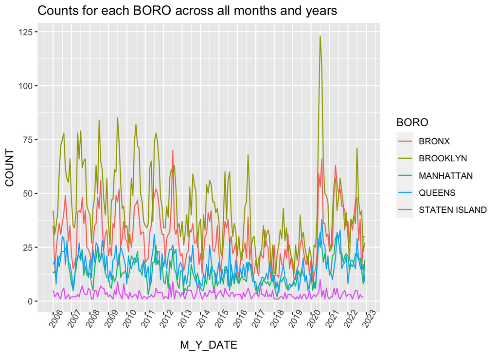

```r
# Plot counts for each BORO across all months and years.
p = ggplot(nypd_data_counts, aes(x = M_Y_DATE, y = COUNT, color = BORO)) + geom_line()
p + scale_x_date(date_breaks = "1 year", date_labels = "%Y") +
  theme(axis.text.x = element_text(angle = 60)) +
  ggtitle("Counts for each BORO across all months and years")
```

The graph is hard to read since there may be a lot of difference between each month for all of the years. It might be useful to increase the timeline to every quarter or every year but we are still able to get some insight from this. We can see that every borough except Staten Island has this kind of peak and dip for each year. This might be indicating that the middle of the year has more shooting incidents than the beginning or end of the year. In Staten Island, the number of cases do not change very much. Queens and Manhattan have a fairly constant range from about 10-30 over this time period. Brooklyn and Bronx have the biggest swings over time for all of the boroughs. There is also a big spike near the middle of 2020 for all of the boroughs but especially Brooklyn and Bronx. This could be a result of the lock down of COVID-19 or it could be multiple other issues related to the areas.

I did the same thing as above but used every quarter instead of every month.

```r
# Make a new column with just quarter and year.
nypd_no_dups_qt= nypd_no_dups %>% mutate(Q_Y_DATE = paste(quarter(OCCUR_DATE), year(OCCUR_DATE), sep = "-"))
head(nypd_no_dups_qt)
```

```
##   INCIDENT_KEY OCCUR_DATE OCCUR_TIME     BORO PRECINCT Q_Y_DATE
## 1    228798151 2021-05-27 21H 30M 0S   QUEENS      105   2-2021
## 2    137471050 2014-06-27 17H 40M 0S    BRONX       40   2-2014
## 3    147998800 2015-11-21  3H 56M 0S   QUEENS      108   4-2015
## 4    146837977 2015-10-09 18H 30M 0S    BRONX       44   4-2015
## 5     58921844 2009-02-19 22H 58M 0S    BRONX       47   1-2009
## 6    219559682 2020-10-21 21H 36M 0S BROOKLYN       81   4-2020
```

```r
# Make that new column a date data type.
nypd_no_dups_qt$Q_Y_DATE = my(nypd_no_dups_qt$Q_Y_DATE)

# Count occurrences after grouping by quarter-year and BORO.
nypd_data_counts = nypd_no_dups_qt %>%
  group_by(Q_Y_DATE, BORO) %>%
  summarize(COUNT = n())
head(nypd_data_counts)
```

```
## # A tibble: 6 × 3
## # Groups:   Q_Y_DATE [2]
##   Q_Y_DATE   BORO          COUNT
##   <date>     <fct>         <int>
## 1 2006-01-01 BRONX            73
## 2 2006-01-01 BROOKLYN        108
## 3 2006-01-01 MANHATTAN        37
## 4 2006-01-01 QUEENS           44
## 5 2006-01-01 STATEN ISLAND    10
## 6 2006-02-01 BRONX            98
```

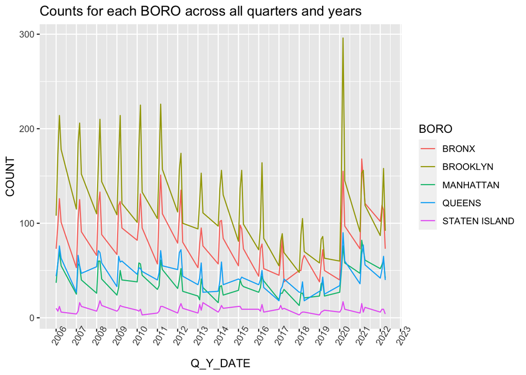

```r
# Plot counts for each BORO across all quarters and years.
p = ggplot(nypd_data_counts, aes(x = Q_Y_DATE, y = COUNT, color = BORO)) + geom_line()
p + scale_x_date(date_breaks = "1 year", date_labels = "%Y") +
  theme(axis.text.x = element_text(angle = 60)) +
  ggtitle("Counts for each BORO across all quarters and years")
```

We can see the peaks in the beginning of the year this time and then a slow dip for the remaining of the year. Also, we see a big increase for 2020 again in Brooklyn.

I did the same thing as above but used every year instead of every quarter or month.

```r
# Make a new column with just year.
nypd_no_dups_y = nypd_no_dups %>% mutate(Y_DATE =  as.Date(paste0(year(OCCUR_DATE), "-01-01")))
head(nypd_no_dups_y)
```

```
##   INCIDENT_KEY OCCUR_DATE OCCUR_TIME     BORO PRECINCT     Y_DATE
## 1    228798151 2021-05-27 21H 30M 0S   QUEENS      105 2021-01-01
## 2    137471050 2014-06-27 17H 40M 0S    BRONX       40 2014-01-01
## 3    147998800 2015-11-21  3H 56M 0S   QUEENS      108 2015-01-01
## 4    146837977 2015-10-09 18H 30M 0S    BRONX       44 2015-01-01
## 5     58921844 2009-02-19 22H 58M 0S    BRONX       47 2009-01-01
## 6    219559682 2020-10-21 21H 36M 0S BROOKLYN       81 2020-01-01
```

```r
# Count occurrences after grouping by year and BORO.
nypd_data_counts = nypd_no_dups_y %>%
  group_by(Y_DATE, BORO) %>%
  summarize(COUNT = n())
head(nypd_data_counts)
```

```
## # A tibble: 6 × 3
## # Groups:   Y_DATE [2]
##   Y_DATE     BORO          COUNT
##   <date>     <fct>         <int>
## 1 2006-01-01 BRONX           398
## 2 2006-01-01 BROOKLYN        673
## 3 2006-01-01 MANHATTAN       220
## 4 2006-01-01 QUEENS          240
## 5 2006-01-01 STATEN ISLAND    35
## 6 2007-01-01 BRONX           373
```

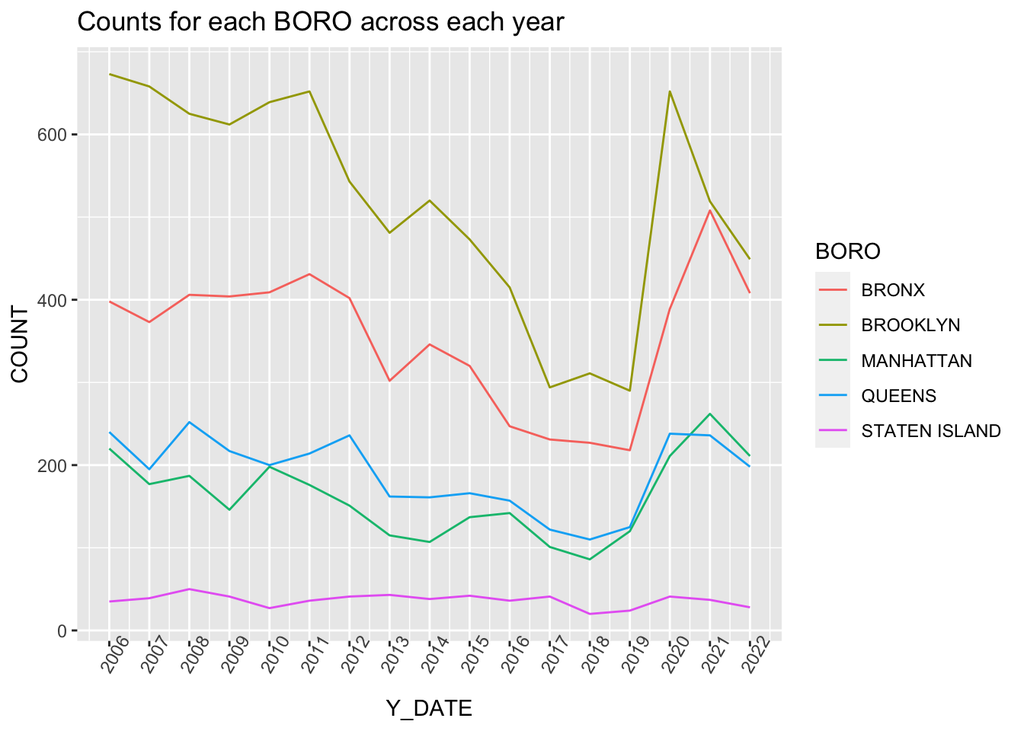

```r
# Plot counts for each BORO across each year.
p = ggplot(nypd_data_counts, aes(x = Y_DATE, y = COUNT, color = BORO)) + geom_line()
p + scale_x_date(date_breaks = "1 year", date_labels = "%Y") +
  theme(axis.text.x = element_text(angle = 60)) +
  ggtitle("Counts for each BORO across each year")
```

We can see that Staten Island stays relatively constant over the years regarding shooting incidents. Queens, Manhattan, Brooklyn, and Bronx all decrease a bit from 2006-2019 but then increase from 2019-2021, after 2021 there is a small decrease in 2022. One thing that we can see in this graph that we did not in the others is that the number of shooting incidents in 2006 is just as high or almost as high as the big spike in 2020. This was hard to see in the other graphs since the points were spread out.

### Analyzing

We can also look more deeply into the data and not just focus on boroughs but focus on the precinct (location within the boroughs). For this we might want to plot each borough separately and maybe look at the shooting incidents over the entire history for the location.

```r
# Start with a dataset that we already made.
head(nypd_no_dups_y)
```

```
##   INCIDENT_KEY OCCUR_DATE OCCUR_TIME     BORO PRECINCT     Y_DATE
## 1    228798151 2021-05-27 21H 30M 0S   QUEENS      105 2021-01-01
## 2    137471050 2014-06-27 17H 40M 0S    BRONX       40 2014-01-01
## 3    147998800 2015-11-21  3H 56M 0S   QUEENS      108 2015-01-01
## 4    146837977 2015-10-09 18H 30M 0S    BRONX       44 2015-01-01
## 5     58921844 2009-02-19 22H 58M 0S    BRONX       47 2009-01-01
## 6    219559682 2020-10-21 21H 36M 0S BROOKLYN       81 2020-01-01
```

```r
# Get the counts and change the BORO to a character data type and the PRECINCT to a factor.
nypd_data_counts <- nypd_no_dups_y %>%
  group_by(BORO, PRECINCT) %>%
  summarize(COUNT = n())
head(nypd_data_counts)
```

```
## # A tibble: 6 × 3
## # Groups:   BORO [1]
##   BORO  PRECINCT COUNT
##   <fct>    <int> <int>
## 1 BRONX       40   734
## 2 BRONX       41   350
## 3 BRONX       42   636
## 4 BRONX       43   597
## 5 BRONX       44   749
## 6 BRONX       45   148
```

```r
nypd_data_counts$PRECINCT = as.factor(nypd_data_counts$PRECINCT)
nypd_data_counts$BORO = as.character(nypd_data_counts$BORO)

# Get the total over all of the years.
nypd_data_total <- nypd_data_counts %>%
  group_by(BORO, PRECINCT) %>%
  summarize(TOTAL = sum(COUNT))
head(nypd_data_total)
```

```
## # A tibble: 6 × 3
## # Groups:   BORO [1]
##   BORO  PRECINCT TOTAL
##   <chr> <fct>    <int>
## 1 BRONX 40         734
## 2 BRONX 41         350
## 3 BRONX 42         636
## 4 BRONX 43         597
## 5 BRONX 44         749
## 6 BRONX 45         148
```

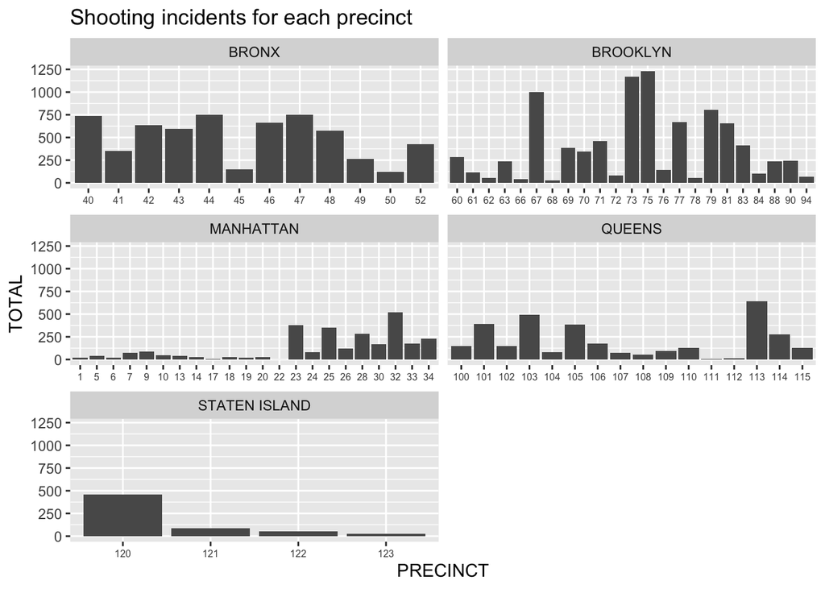

```r
# Plot the counts for each PRECINCT for each BORO.
p = ggplot(nypd_data_total, aes(x = PRECINCT, y = TOTAL)) +
  geom_bar(stat = "identity") +
  facet_wrap(~BORO, ncol = 2, scales = "free_x")
p + theme(axis.text.x = element_text(size = 6 )) +
  ggtitle("Shooting incidents for each precinct")
```

We can see that some precincts have more cases than others, particularly in Brooklyn which has the most shooting incidents. In Brooklyn, we can see that precincts 67, 73, 75, 77, 79, and 81 have higher shooting incidents. We also a similar phenomenon in other boroughs. We might be able to isolate these precincts with higher shoot incidents and map the incidents over time (date). We could then possibly predict why these areas have more shooting incidents than others and develop some way to lower them.

### Model

We could also predict the number of incidents that will happen for which months in NYC. Since we know which precincts have the most incidents then we could focus intervention efforts in those areas first. We could make a plan to help reduce the shooting incidents in that area. One example could be to increase police activity during those months in those areas.

```r
# Get our data and get counts for each month and year.
head(nypd_no_dups_y)
```

```
##   INCIDENT_KEY OCCUR_DATE OCCUR_TIME     BORO PRECINCT     Y_DATE
## 1    228798151 2021-05-27 21H 30M 0S   QUEENS      105 2021-01-01
## 2    137471050 2014-06-27 17H 40M 0S    BRONX       40 2014-01-01
## 3    147998800 2015-11-21  3H 56M 0S   QUEENS      108 2015-01-01
## 4    146837977 2015-10-09 18H 30M 0S    BRONX       44 2015-01-01
## 5     58921844 2009-02-19 22H 58M 0S    BRONX       47 2009-01-01
## 6    219559682 2020-10-21 21H 36M 0S BROOKLYN       81 2020-01-01
```

```r
nypd_data_counts = nypd_no_dups_y %>%
  group_by(month(OCCUR_DATE), year(OCCUR_DATE)) %>%
  summarize(COUNT = n())
head(nypd_data_counts)
```

```
## # A tibble: 6 × 3
## # Groups:   month(OCCUR_DATE) [1]
##   `month(OCCUR_DATE)` `year(OCCUR_DATE)` COUNT
##                 <dbl>              <dbl> <int>
## 1                   1               2006   112
## 2                   1               2007    90
## 3                   1               2008    99
## 4                   1               2009    79
## 5                   1               2010    86
## 6                   1               2011    83
```

```r
# Change the column names and make MONTH a factor.
colnames(nypd_data_counts) = c("MONTH", "YEAR", "COUNT")
nypd_data_counts$MONTH = as.factor(nypd_data_counts$MONTH)

# Create our linear model and summarize it.
lm_incidents = lm(COUNT ~ MONTH + YEAR, data = nypd_data_counts)
summary(lm_incidents)
```

```
##
## Call:
## lm(formula = COUNT ~ MONTH + YEAR, data = nypd_data_counts)
##
## Residuals:
##     Min      1Q  Median      3Q     Max
## -61.727 -17.055  -2.569  14.885 108.782
##
## Coefficients:
##              Estimate Std. Error t value Pr(>|t|)
## (Intercept) 4291.9943   804.7285   5.333 2.71e-07 ***
## MONTH2       -18.4706     9.5893  -1.926 0.055568 .
## MONTH3        -2.3529     9.5893  -0.245 0.806432
## MONTH4        12.5882     9.5893   1.313 0.190845
## MONTH5        35.3529     9.5893   3.687 0.000296 ***
## MONTH6        49.4706     9.5893   5.159 6.19e-07 ***
## MONTH7        66.4706     9.5893   6.932 6.22e-11 ***
## MONTH8        64.2353     9.5893   6.699 2.29e-10 ***
## MONTH9        38.0000     9.5893   3.963 0.000105 ***
## MONTH10       24.7059     9.5893   2.576 0.010738 *
## MONTH11        9.6471     9.5893   1.006 0.315676
## MONTH12       14.0000     9.5893   1.460 0.145943
## YEAR          -2.0911     0.3996  -5.234 4.36e-07 ***
## ---
## Signif. codes:  0 '***' 0.001 '**' 0.01 '*' 0.05 '.' 0.1 ' ' 1
##
## Residual standard error: 27.96 on 191 degrees of freedom
## Multiple R-squared:  0.5107, Adjusted R-squared:  0.4799
## F-statistic: 16.61 on 12 and 191 DF,  p-value: < 2.2e-16
```

```r
# Predict new data.
pred = predict(lm_incidents, newdata = data.frame(MONTH = factor(1:12), YEAR = 2023))
pred
```

```
##         1         2         3         4         5         6         7         8
##  61.70956  43.23897  59.35662  74.29779  97.06250 111.18015 128.18015 125.94485
##         9        10        11        12
##  99.70956  86.41544  71.35662  75.70956
```

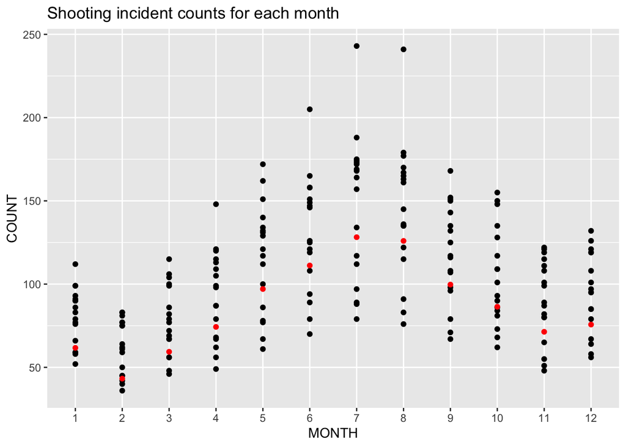

```r
# Plot new data and old data.
pred_df = data.frame(pred)
pred_df$MONTH = 1:12
colnames(pred_df) = c("COUNT", "MONTH")
ggplot(data = nypd_data_counts, aes(x = MONTH, y = COUNT)) + geom_point() +
  geom_point(data = pred_df, aes(x = MONTH, y = COUNT), color = "red") +
  ggtitle("Shooting incident counts for each month")
```

```r
nypd_data_counts %>% filter(MONTH==7) %>% summarize(mean(COUNT))
```

```
## # A tibble: 1 × 2
##   MONTH `mean(COUNT)`
##   <fct>         <dbl>
## 1 7               147
```

We can see in our model that not all months are statistically significant so we might want to add other predictors to the model or change the model slightly. However, we can see that May - October are statistically significant. This means that they are statistically different from the intercept which is actually the value for January. When looking at the predicted values (counts for the new months) we see that it ranges from ~43 (Feb.) to ~130 (July). When looking at the historic data, these numbers seem reasonable. When looking at the plot, we can see our red dots (our predictions) are not in the middle of each month, which is okay. We really need more data to test whether the model can make good predictions for the counts on certain months. Also, the predictions are not just the mean of each month. Testing the month of July, the mean is 147 and the prediction is 128. We might want to pair this with our highest incidents in certain precincts and plan prevention efforts, but based on these predictions we would want to focus on months May - September.

## Conclusion and Bias

In this analysis, we have investigated the shooting incidents in the boroughs of NYC over time to see if shooting incidents have increased since 2006. We have found that shooting incidents in Queens, Manhattan, Brooklyn, and Bronx all decrease a bit from 2006-2019 but then increase from 2019-2021 back to around the same levels as 2006, and after 2021 there is a small decrease into 2022. Staten Island seems to stay relatively constant over the years. We also found that the middle of the year might have more incidents than in the beginning or end of the year (colder months). Finally, we saw that some areas within the boroughs (precincts) had more shooting incidents than other areas. If we investigated those areas more, we might be able to develop a plan to reduce the shooting incidents there.

This analysis does not come without bias. For example, regarding this historical data there could have been police bias where the police are in these areas more often causing more reports in certain precincts and not in others. There could also be a reporting bias where some shooting incidents are not recorded for whatever reason. There could also be a sourcing bias for where this data was gathered and more data could be available to complement or add to this data. Finally, there is a personal bias when conducting this analysis and to mitigate that I decided to look at time vs boroughs which I have no affiliation with.